# Retail Project

## Residual Diagnostics

We will first do the residual daignostics for the ETS model.

```r
best_fit_ETS <- train_retail %>%
  model(ETS(Turnover ~ error("M") + trend("A",phi = 0.9) +season("M")))

best_fit_ARIMA <- train_retail %>%
  model(ARIMA(box_cox(Turnover, lambda) ~ pdq(1,0,1)+PDQ(0,1,1)))

augment(best_fit_ETS) %>% features(.innov, ljung_box, dof = 2, lag = 10)#here is the code to do the ljung box test
```

```
## # A tibble: 1 x 5
##   State      Industry               .model                     lb_stat lb_pvalue
##   <chr>      <chr>                  <chr>                        <dbl>     <dbl>
## 1 Queensland Other retailing n.e.c. "ETS(Turnover ~ error(\"M~    20.9   0.00743
```

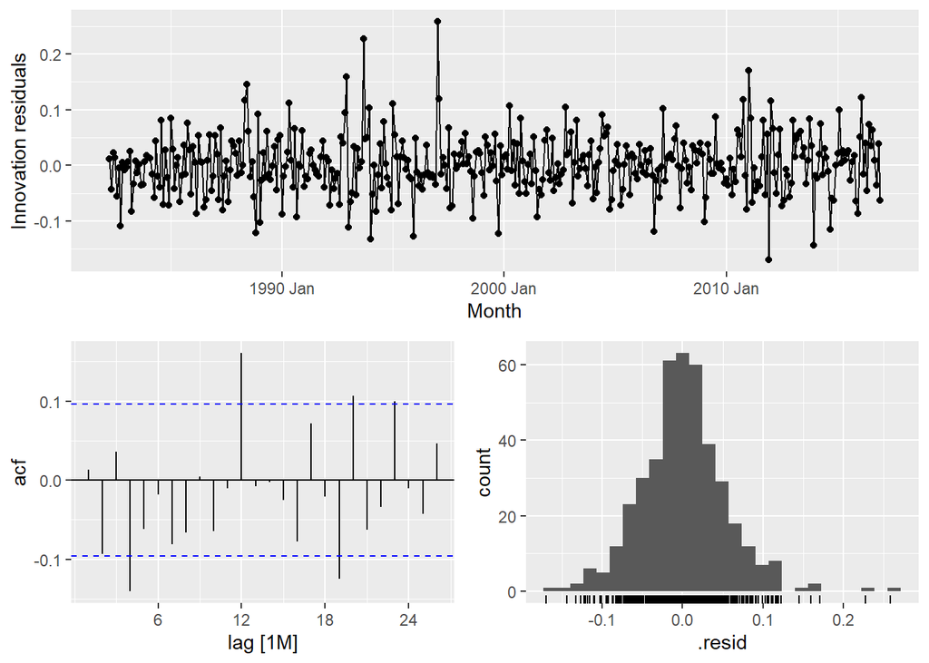

```r
best_fit_ETS %>% gg_tsresiduals()##here is the code to get the ACF and PCF plot
```

```r
#WHat i need to do now is figure out how to use the Jung box test as well as figure out how to use the ACF plots.
```

From Visual inspection the residuals do appear to be white noise. For the lb_value, we actually get a relatively small p value. This could be evidence against the null that the graph is not distinguishable from white noise series. Meaning that there could still be some form of trend that has not been taken into account for yet.

The residual histogram does appear to be centered around 0. However if we look at the ACF plot, there are a number of spikes that leave the blue lines. This suggests there still could be some variation that is not fully explaining the model.

we will next do some residual diagnostics for the best ARIMA model

```r
augment(best_fit_ARIMA) %>% features(.innov, ljung_box, dof = 2, lag = 10)#here is the code to do the ljung box test
```

```
## # A tibble: 1 x 5
##   State      Industry               .model                     lb_stat lb_pvalue
##   <chr>      <chr>                  <chr>                        <dbl>     <dbl>
## 1 Queensland Other retailing n.e.c. ARIMA(box_cox(Turnover, l~    8.61     0.376
```

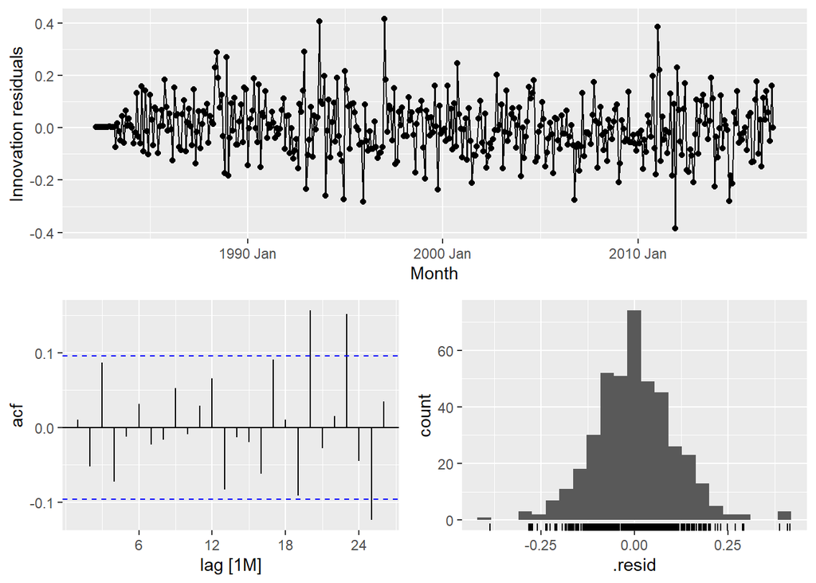

```r
best_fit_ARIMA %>% gg_tsresiduals()
```

Firstly the residuals on visual inspection to appear to be white noise. The results here prove better than that of the ETS model. From the ljung box test we get the p value of 0.376. Because this is a relatively large p value, we can conclude the residuals are not distinguishable from white noise. The acf plot does show some significant spikes which maybe could still indicate that there is some variation that is not being taken into account of, but there are less of these examples that cross the bars than that of the ETS model. Again the residuals to seem to center around 0 which is a good indicator there is no further variation to be taken into account for by the model.

## Preferred model

We will now determine which model we think is best with reference to the test set.

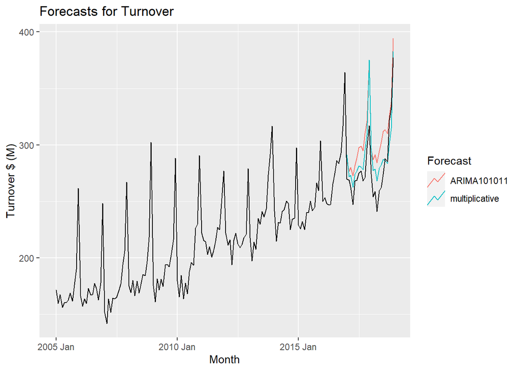

```r
best_fit_both <- train_retail %>%
  model(multiplicative = ETS(Turnover ~ error("M") + trend("A",phi = 0.9)+ season("M")),
        `ARIMA101011` = ARIMA(box_cox(Turnover, lambda) ~ pdq(1,0,1)+PDQ(0,1,1)))


fc <- best_fit_both %>% forecast(h = "2 years")
fc %>%
  autoplot(
    myseries%>% filter(year(Month)>=2005),
    level = NULL
  ) + labs(
    y = "Turnover $ (M)",
    title = "Forecasts for Turnover"
  ) +
  guides(colour = guide_legend(title = "Forecast"))
```

```r
accuracy(fc, test_retail)
```

```
## # A tibble: 2 x 12
##   .model    State Industry .type    ME  RMSE   MAE   MPE  MAPE  MASE RMSSE  ACF1
##   <chr>     <chr> <chr>    <chr> <dbl> <dbl> <dbl> <dbl> <dbl> <dbl> <dbl> <dbl>
## 1 ARIMA101~ Quee~ Other r~ Test  -25.5  28.4  25.5 -9.32  9.32   NaN   NaN 0.398
## 2 multipli~ Quee~ Other r~ Test  -12.0  19.5  15.5 -4.50  5.59   NaN   NaN 0.486
```

Visually it would appear the the multiplicative ETS model captures the variation better than that of the ARIMA model. Again this can be seen in the RMSE scores in that the ETS multiplicative model has the best root mean square errors.

## THe Full data set.

ETS:

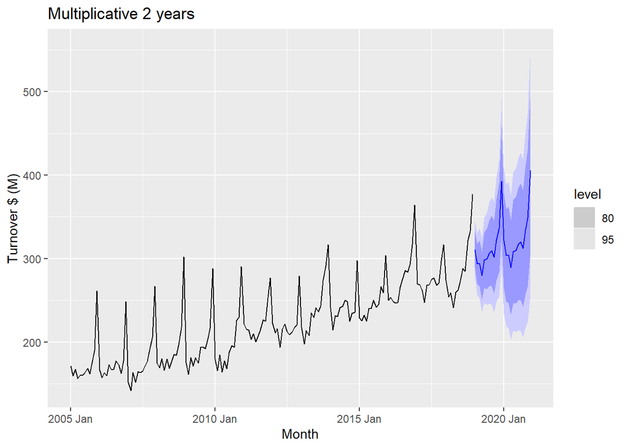

```r
best_fit_both <- myseries %>%
  model(multiplicative = ETS(Turnover ~ error("M") + trend("A",phi = 0.9)+ season("M")),
        `ARIMA101011` = ARIMA(box_cox(Turnover, lambda) ~ pdq(1,0,1)+PDQ(0,1,1)))


fc <- best_fit_both %>% forecast(h = "2 years")

fc %>% filter(`.model` == "multiplicative") %>%
  autoplot(
    myseries%>% filter(year(Month)>=2005)) + labs(y = "Turnover $ (M)", title = "Multiplicative 2 years")
```

We will now do the forecasting with the prediction interval for the arima model.

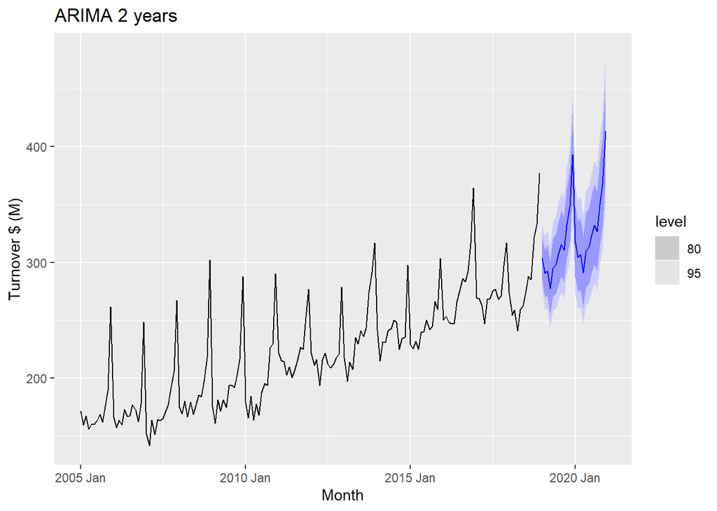

```r
fc %>% filter(`.model` == "ARIMA101011") %>%
  autoplot(
    myseries%>% filter(year(Month)>=2005)
  ) + labs(y = "Turnover $ (M)", title = "ARIMA 2 years")
```

The prediction interval for the ARIMA model does appear to be tighter than that of the ETS model.

## Comparison to real data

To perform this we will use the readabs function, download the series than run a loop that will append it to the data.

```r
library(readabs)
##if we have this library we cana use this.
real_data <- read_abs_series("A3349881A")
```

```
## Finding URLs for tables corresponding to ABS series ID
```

```
## Attempting to download files from series ID , Retail Trade, Australia
```

```
## Extracting data from downloaded spreadsheets
```

```
## Tidying data from imported ABS spreadsheets
```

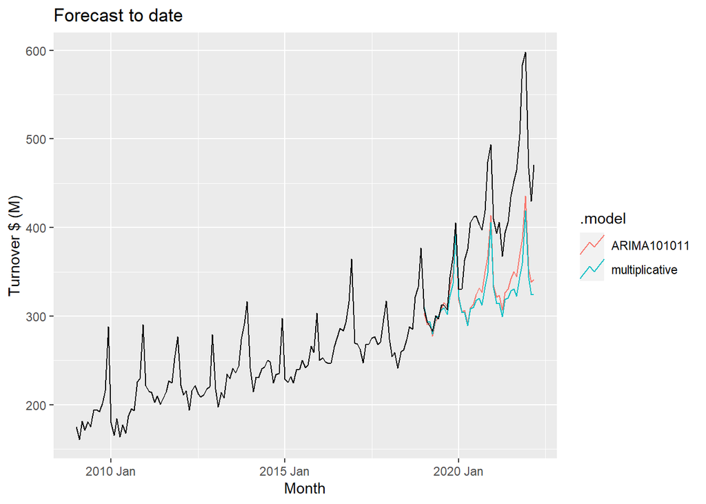

```r
real_data2 <- real_data %>% select(date,value)

##from this it is already in the date format.
real_data2 <- real_data2 %>%
  filter(year(date) >= 2019) #%>% filter(year(date)<= 2020)

colnames(real_data2) <- c("Month","Turnover")


##we know that we need to add 24 elements


for (i in c(1:nrow(real_data2))){

  myseries <- append_row(myseries)##we will add a row to the data
  ##if it is in the right order than it should work correctly
  ##by inspection the data is already sorted so it works fine
  myseries[nrow(myseries), 5]<- real_data2$Turnover[i]##add the turn over

  myseries[nrow(myseries), 3]<-"A3349881A"

}
##we know have the full data set and can plot it
fc_last <- best_fit_both %>% forecast(h = "39 months")

fc_last %>% autoplot(myseries%>% filter(year(Month)>=2009),level = NULL) + labs(y = "Turnover $ (M)", title = "Forecast to date")
```

here we will produce the accuracy score by making a new test set

```r
test_retail_real <- myseries %>%
  filter(year(Month) >= 2019)

accuracy(fc, test_retail_real)
```

```
## # A tibble: 2 x 12
##   .model    State Industry .type    ME  RMSE   MAE   MPE  MAPE  MASE RMSSE  ACF1
##   <chr>     <chr> <chr>    <chr> <dbl> <dbl> <dbl> <dbl> <dbl> <dbl> <dbl> <dbl>
## 1 ARIMA101~ Quee~ Other r~ Test   38.1  54.6  39.1  9.36  9.69   NaN   NaN 0.890
## 2 multipli~ Quee~ Other r~ Test   42.3  60.3  43.3 10.4  10.7    NaN   NaN 0.883
```

We can see here that for both of these forecasts as time increased, the forecasts changed drastically. The first year for both models was very accurate and as time increased both models could not handle the huge jumps in turnover. The RMSE for the ARIMA model was calculated to be 54.57, while the multiplicative had an RMSE of 60.34685, implying for this extrapolation of data the ARIMA performed slightly better.

## Discussion of benifits and limitations of the data.

It is hard to compare models from different classes as a simple metric like AIC cannot be used as they are calculated differently for both the ARIMA and ETS models. One important aspect to note is the confidence intervals. The confidence intervals for the ETS model are clearly much larger than that of the ARIMA which could be taken into consideration for future modelling. We do notice that both models really struggle to pick up the large increase in turn over seen in 2021 and 2022. Both models do appear to pick up well on the seasonality, and in this regard I would say the two model performances are on par.

The other issue is that for the testing set the ETS model performed better based on the RMSE while for the extrapolation into today data it performs worse than that of the ARIMA model.

It is hard to overall decide which model to select, as based on the different metrics of AIC, RMSE for the initial testing vs extrapolation to today data, different models come out on top. Instead I would suggest the combination of many different models to predict it. What if we were to take the average of each of the predictions from these two models and see how that performs?